# Chapter 6 Marker Identification

```r
# libraries for this chapter
library(tidyverse)
library(Seurat)
library(data.table)
library(HGNChelper)
```

# Load RData

Load the RData which contains all files from the previous chapter.

```r
load("data/intermediate_data/chapter5.RData")
```

# 1. Find marker genes

## 1.1 `FindAllMarkers`

This type of analysis is typically for evaluating a single sample group/condition. With the `FindAllMarkers` function, we are comparing each cluster to all other clusters to identify potential marker genes. The cells in each cluster are treated as replicates, and essentially a differential expression analysis is performed with some statistical test. By default, the test is Wilcoxon Rank Sum test.

The `FindAllMarkers` function has three arguments to determine if a gene is a marker gene.

- `logfc.threshold` Limit testing to genes that show, on average, at least an X-fold difference (log-scale) between the two groups of cells. The default is 0.25. Increasing `logfc.threshold` speeds up the function but can miss weaker signals.
- `min.pct` Only test genes that are detected in a minimum fraction of cells in either of the two populations. It is meant to speed up the function by not testing infrequently expressed genes. The default is 0.1.
- `only.pos` Only return positive markers (FALSE by default).

One may change the arguments depending on how stringent to be.

We look at the marker genes in the clusters in sample “treated”.

```r
treated.markers <- FindAllMarkers(subset(integrate.filtered.rna, subset = Sample_Name == "treated"),
                                  assay = "RNA",
                                  only.pos = TRUE,
                                  min.pct = 0.25,
                                  logfc.threshold = 0.25)
```

Let’s look at the top 2 significant marker genes in each cluster.

```r
treated.markers %>%
    group_by(cluster) %>%
    slice_max(n = 2, order_by = avg_log2FC)
```

```
# A tibble: 26 × 7
# Groups:   cluster [13]
       p_val avg_log2FC pct.1 pct.2 p_val_adj cluster gene
       <dbl>      <dbl> <dbl> <dbl>     <dbl> <fct>   <chr>
 1 9.89e-158       2.63 0.744 0.212 1.91e-153 0       MAL
 2 3.62e-104       2.10 0.734 0.379 7.01e-100 0       PCED1B-AS1
 3 0               5.06 0.961 0.055 0         1       GNLY
 4 3.65e-259       4.13 0.892 0.108 7.07e-255 1       CCL5
 5 5.52e- 12       1.07 0.75  0.515 1.07e-  7 2       HSPD1
 6 6.86e- 17       1.00 0.957 0.787 1.33e- 12 2       NPM1
 7 5.53e- 82       2.41 0.594 0.119 1.07e- 77 3       RGS1
 8 5.81e- 25       1.82 0.304 0.09  1.12e- 20 3       FOXP3
 9 1.24e-122       2.25 0.916 0.276 2.39e-118 4       LTA
10 1.65e-159       1.97 0.941 0.225 3.20e-155 4       MIR155HG
# ℹ 16 more rows
```

We get a table with the information on marker genes.

`p_val` P-value before multiple testing.

`avg_log2FC` Log2 fold change on the average gene expression between one cluster and the rest of cluster combined.

`pct.1` Percentage of cells expressing the gene in one group. Here is one cluster.

`pct.2` Percentage of cells expressing the gene in another group. Here is the rest of cluster combined.

`p_val_adj` p-value with multiple testing correction.

## 1.2 `FindConservedMarkers`

We have two samples, naïve and treated. We can find conserved markers between the conditions with the function, `FindConservedMarkers`.

This function internally separates out cells by sample group/condition, then performs differential gene expression testing for a single specified cluster against all other clusters.

Gene-level p-values are computed for each condition and then combined across groups using meta-analysis methods from the `MetaDE` R package.

Many of the arguments in `FindConservedMarkers` are shared with `FindAllMarkers`. Here, we list some additional arguments when using `FindConservedMarkers`.

- `ident.1` This function only evaluates one cluster at a time; here, you would specify the cluster of interest.
- `grouping.var` The variable (column name) in your metadata specifies the separation of cells into groups.

```r
fcm <- FindConservedMarkers(integrate.filtered.rna,
                     assay = "RNA",
                     ident.1 = "1",
                     grouping.var = "Sample_Name",
                     only.pos = TRUE,
                     min.diff.pct = 0.25,
                     min.pct = 0.25,
                     logfc.threshold = 0.25)

head(fcm)
```

```
       naive_p_val naive_avg_log2FC naive_pct.1 naive_pct.2 naive_p_val_adj
GNLY  0.000000e+00         4.823298       0.947       0.024    0.000000e+00
GZMA 8.973490e-245         3.778985       0.835       0.041   1.736101e-240
PRF1 1.103550e-125         2.671046       0.453       0.021   2.135038e-121
NKG7 1.504853e-212         3.572770       0.823       0.060   2.911439e-208
CCL5 9.363098e-161         3.319940       0.852       0.120   1.811479e-156
CST7 5.390018e-149         3.014122       0.634       0.053   1.042807e-144
     treated_p_val treated_avg_log2FC treated_pct.1 treated_pct.2
GNLY  0.000000e+00           5.060457         0.961         0.055
GZMA  0.000000e+00           3.813904         0.976         0.082
PRF1  0.000000e+00           3.855625         0.907         0.068
NKG7 8.396253e-261           3.398566         0.982         0.150
CCL5 3.653151e-259           4.133251         0.892         0.108
CST7 6.882951e-236           3.135928         0.759         0.068
     treated_p_val_adj      max_pval minimump_p_val
GNLY      0.000000e+00  0.000000e+00   0.000000e+00
GZMA      0.000000e+00 8.973490e-245   0.000000e+00
PRF1      0.000000e+00 1.103550e-125   0.000000e+00
NKG7     1.624423e-256 1.504853e-212  1.679251e-260
CCL5     7.067750e-255 9.363098e-161  7.306301e-259
CST7     1.331645e-231 5.390018e-149  1.376590e-235
```

We also get a table with information on marker genes. The statistics are computed for each group (naïve vs. treated), and the last two columns are the combined p-value across the two groups.

- `condition_p_val` P-value before multiple testing.
- `condition_avg_log2FC` Log2 fold change on the average of gene expression between one cluster and the rest of the clusters combined.
- `condition_pct.1` Percentage of cells expressing the gene in one group.
- `condition_pct.2` Percentage of cells expressing the gene in another group.
- `condition_p_val_adj` P-value with multiple testing correction.

**Note**

The more significant the difference between `pct.1` and `pct.2`, the higher the confidence for the marker gene. If `pct.1` is 0.9 and `pct.2` is 0.8, it is not as interesting as if `pct.2` is 0.1.

Marker genes express in a specific cell type. If `pct.1` is low, such as 0.3, it is not as interesting as if it is 0.9.

We can visualize the marker gene expression by `FeaturePlot` and `VlnPlot`.

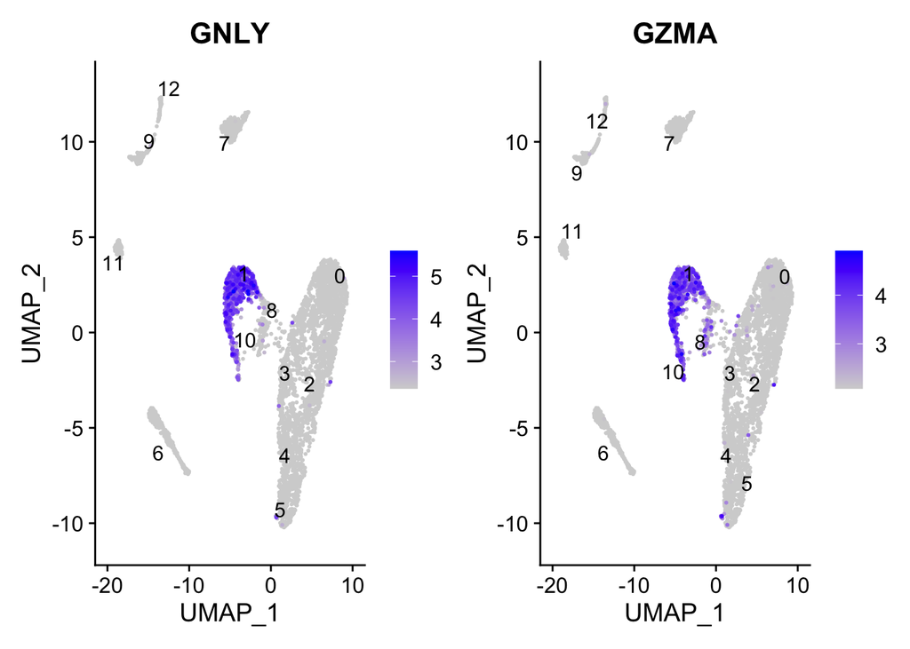

```r
FeaturePlot(object = integrate.filtered.rna,
            features = c("GNLY", "GZMA"),
            order = TRUE,
            min.cutoff = 'q10',
            label = TRUE,
            repel = TRUE)
```

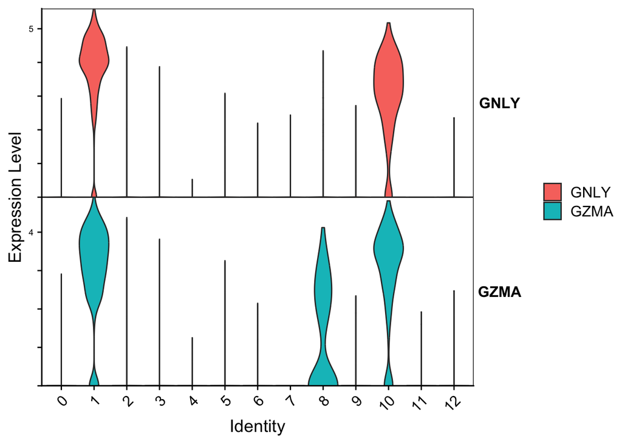

```r
VlnPlot(object = integrate.filtered.rna,
        features = c("GNLY", "GZMA"),
        stack = T, flip = T)
```

## 1.3 `FindMarkers`

We can use the `FindMarkers` to determine the differentially expressed genes between two clusters.

```r
example_findmarkers <- FindMarkers(integrate.filtered.rna,
                          assay = "RNA",
                          ident.1 = 1,
                          ident.2 = 2) %>%
  rownames_to_column("gene")
```

# 2. Automatic annotation

So far, we already look at the marker genes based on knowledge (manual annotation) and between clusters by differential expression analysis. The manual annotation usually takes time, and we might need to go back and forth to annotate the clusters. Another way to annotate the clusters is through the automatic annotation.

## 2.1 Reference-based

We look at the publicly available dataset with annotation and build a reference set based on its information. Then we can “transfer” the annotation from the reference to the query. Seurat provides the interface to connect with `Azimuth`.

**Note**

Because the annotation information is based on the reference set, the reference ideally is similar to the query. They may come from the same tissue, same organism, similar experimental procedure, etc.

```r
integrate.filtered.rna <- Azimuth::RunAzimuth(integrate.filtered.rna,
                                              reference = "pbmcref",
                                              verbose = F)
```

```
An AzimuthData object - reference version: 1.0.0
Contains 3 meta.data field(s) to transfer.
```

We can look at the automatic annotation on UMAP.

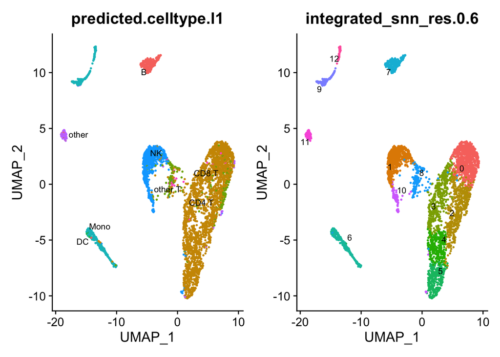

```r
p1 <- DimPlot(integrate.filtered.rna, reduction = "umap",
              group.by = "predicted.celltype.l1",
              label = TRUE, label.size = 3 ,repel = TRUE) +
  NoLegend()

p2 <- DimPlot(integrate.filtered.rna, reduction = "umap",
              group.by = "integrated_snn_res.0.6",
              label = TRUE, label.size = 3 ,repel = TRUE) +
  NoLegend()

p1|p2
```

## 2.1 Marker-based

We use ScType (https://github.com/IanevskiAleksandr/sc-type/blob/master/README.md) to annotate cell population based on known immune markers.

ScType also has an open source portal: https://sctype.app/.

```r
# load ScType R functions
source("https://raw.githubusercontent.com/IanevskiAleksandr/sc-type/master/R/gene_sets_prepare.R"); source("https://raw.githubusercontent.com/IanevskiAleksandr/sc-type/master/R/sctype_score_.R")

# get cell-type-specific gene sets from our in-built database (DB)
# list downloaded from https://raw.githubusercontent.com/IanevskiAleksandr/sc-type/master/ScTypeDB_short.xlsx
# e.g. Immune system, Liver, Pancreas, Kidney, Eye, Brain
gs_list <-  gene_sets_prepare("data/ScTypeDB_short.xlsx", "Immune system")

# assign cell types
# NOTE: scRNAseqData parameter should correspond to your input scRNA-seq matrix.
# In case Seurat is used, it is either pbmc[["RNA"]]@scale.data (default), pbmc[["SCT"]]@scale.data, in case sctransform is used for normalization,
# or pbmc[["integrated"]]@scale.data, in case a joint analysis of multiple single-cell datasets is performed.
es.max <-  sctype_score(scRNAseqData = integrate.filtered.rna@assays[["integrated"]]@scale.data,
                        scaled = TRUE,
                        gs = gs_list$gs_positive,
                        gs2 = gs_list$gs_negative)

# merge by cluster
cL_resutls = do.call("rbind", lapply(unique(integrate.filtered.rna@meta.data$integrated_snn_res.0.6), function(cl){
    es.max.cl = sort(rowSums(es.max[ ,rownames(integrate.filtered.rna@meta.data[integrate.filtered.rna@meta.data$integrated_snn_res.0.6==cl, ])]), decreasing = !0)
    head(data.frame(cluster = cl, type = names(es.max.cl), scores = es.max.cl, ncells = sum(integrate.filtered.rna@meta.data$integrate.filtered.rna==cl)), 10)
}))

sctype_scores = cL_resutls %>% group_by(cluster) %>% top_n(n = 1, wt = scores)

# set low-confident (low ScType score) clusters to "unknown"
sctype_scores$type[as.numeric(as.character(sctype_scores$scores)) < sctype_scores$ncells/4] = "Unknown"
```

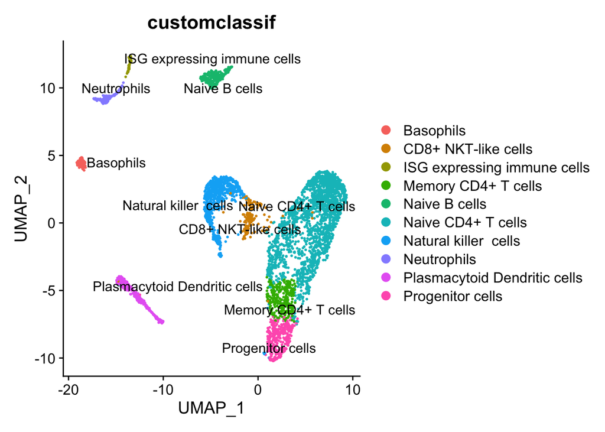

```r
integrate.filtered.rna@meta.data$customclassif = ""

for(j in unique(sctype_scores$cluster)){
  cl_type = sctype_scores[sctype_scores$cluster==j,];
  integrate.filtered.rna@meta.data$customclassif[integrate.filtered.rna@meta.data$integrated_snn_res.0.6 == j] = as.character(cl_type$type[1])
}

DimPlot(integrate.filtered.rna, reduction = "umap", label = TRUE, repel = TRUE, group.by = 'customclassif')
```

# 3. Save

Save the files into RData for documentation.

```r
# save(integrate.filtered.rna, expMat, file = "data/intermediate_data/chapter6.RData")
```